# 3: Logistic regression

- Describe your work and results clearly.
- Assume the reader has an introductory course level understanding of writing and reading R code as well as statistical methods.
- Assume the reader has no previous knowledge of your data or the more advanced methods you are using.

## Read data and describe data briefly

```r
# read data
alc <- read.csv("D:\\做一个合格的博士\\Courses\\Open Data\\IODS-project\\data\\alc.csv")

# check data
library(dplyr)
glimpse(alc)
```

```
## Rows: 370
## Columns: 37
## $ school      <chr> "GP", "GP", "GP", "GP", "GP", "GP", "GP", "GP", "GP", "GP"…
## $ sex         <chr> "F", "F", "F", "F", "F", "M", "M", "F", "M", "M", "F", "F"…
## $ age         <int> 18, 17, 15, 15, 16, 16, 16, 17, 15, 15, 15, 15, 15, 15, 15…
## $ address     <chr> "U", "U", "U", "U", "U", "U", "U", "U", "U", "U", "U", "U"…
## $ famsize     <chr> "GT3", "GT3", "LE3", "GT3", "GT3", "LE3", "LE3", "GT3", "L…
## $ Pstatus     <chr> "A", "T", "T", "T", "T", "T", "T", "A", "A", "T", "T", "T"…
## $ Medu        <int> 4, 1, 1, 4, 3, 4, 2, 4, 3, 3, 4, 2, 4, 4, 2, 4, 4, 3, 3, 4…
## $ Fedu        <int> 4, 1, 1, 2, 3, 3, 2, 4, 2, 4, 4, 1, 4, 3, 2, 4, 4, 3, 2, 3…
## $ Mjob        <chr> "at_home", "at_home", "at_home", "health", "other", "servi…
## $ Fjob        <chr> "teacher", "other", "other", "services", "other", "other",…
## $ reason      <chr> "course", "course", "other", "home", "home", "reputation",…
## $ guardian    <chr> "mother", "father", "mother", "mother", "father", "mother"…
## $ traveltime  <int> 2, 1, 1, 1, 1, 1, 1, 2, 1, 1, 1, 3, 1, 2, 1, 1, 1, 3, 1, 1…
```

[output cut: 24 more lines]

The data set has 370 observations and 37 variables. The names of variables are listed in the first column in the output. The types of data in this data set are character, integer, numeric, and logic.

## Choose 4 variables and present hypothesis

“sex”, “G3”, “failures”, and “absences” variables are chose. The hypothesis are: 1. There might be gender differences in alcoholic consumption, with male more likely to have high alcohol consumption compared to women. 2. There might be a negative correlation between alcohol consumption and final year grades. 3. Students who have a history of academic failures (higher values) might be more prone to high alcohol consumption. 4.Higher rates of school absences may be associated with high alcoholic consumption.

## Distribution of chosen variables and their relationships with alcoholic consumption

### sex and alcohol consumption

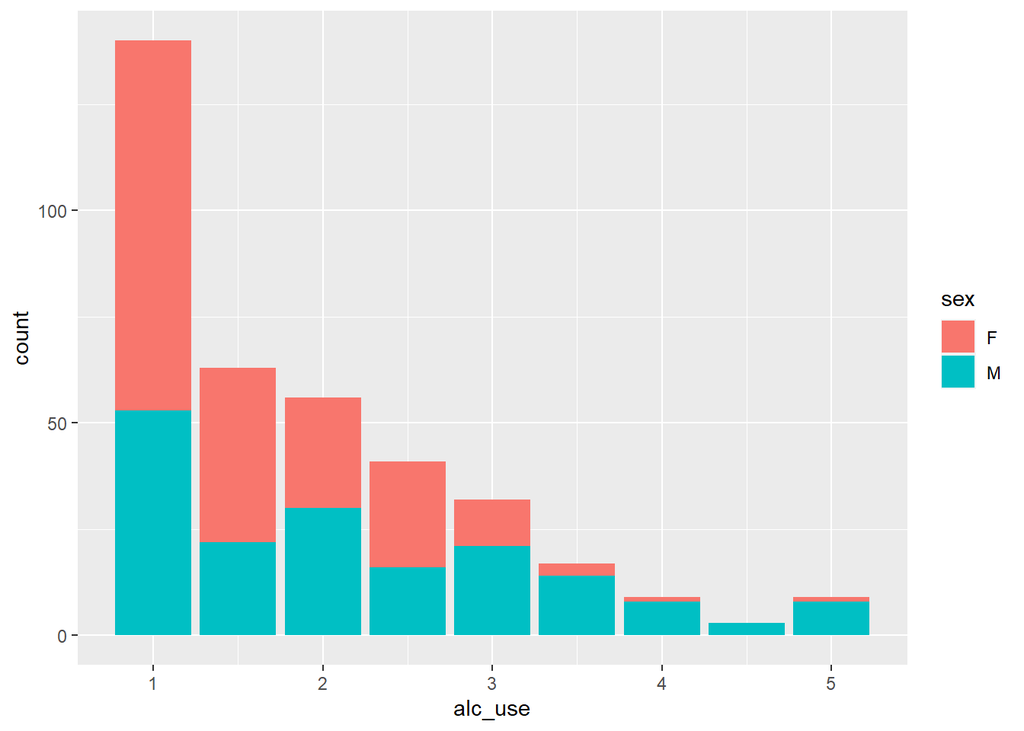

```r
library(dplyr)
math <- read.table("https://raw.githubusercontent.com/KimmoVehkalahti/Helsinki-Open-Data-Science/master/datasets/student-mat.csv", sep=";", header=TRUE)
por <- read.table("https://raw.githubusercontent.com/KimmoVehkalahti/Helsinki-Open-Data-Science/master/datasets/student-por.csv", sep=";", header=TRUE)
free_cols <- c("failures","paid","absences","G1","G2","G3")
join_cols <- setdiff(colnames(por), free_cols)
math_por <- inner_join(math, por, by = join_cols, suffix = c(".math", ".por"))
alc <- select(math_por, all_of(join_cols))
for(col_name in free_cols) {
  two_cols <- select(math_por, starts_with(col_name))
  first_col <- select(two_cols, 1)[[1]]
  if(is.numeric(first_col)) {
    alc[col_name] <- round(rowMeans(two_cols))
  } else {
    alc[col_name] <- first_col
  }
}
library(ggplot2)

# define a new column alc_use by combining weekday and weekend alcohol use
alc <- mutate(alc, alc_use = (Dalc + Walc) / 2)

# initialize a plot of alcohol use
g1 <- ggplot(data = alc, aes(x = alc_use), position = "dodge", stat = "count")

# define the plot as a bar plot and draw it
g1 + geom_bar(aes(fill = sex))
```

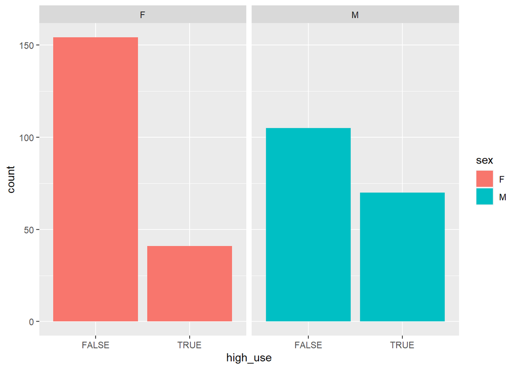

```r
# define a new logical column 'high_use'
alc <- mutate(alc, high_use = alc_use > 2)

# initialize a plot of 'high_use'
g2 <- ggplot(data = alc, aes(x = high_use))

# draw a bar plot of high_use by sex
g2 + geom_bar(aes(fill = sex), position = "dodge", stat = "count") + facet_wrap(~sex)
```

### box plots of other varibales and alcohoc consumption

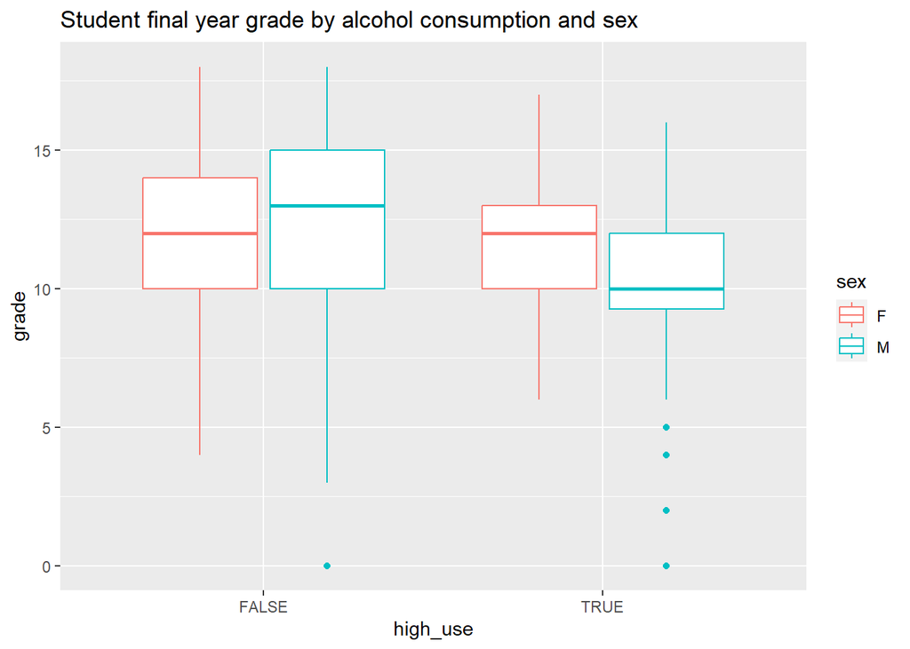

```r
# initialize a plot of high_use and G3
g1 <- ggplot(alc, aes(x = high_use, y = G3, col =sex))

# define the plot as a boxplot and draw it
g1 + geom_boxplot() + ylab("grade") + ggtitle("Student final year grade by alcohol consumption and sex")
```

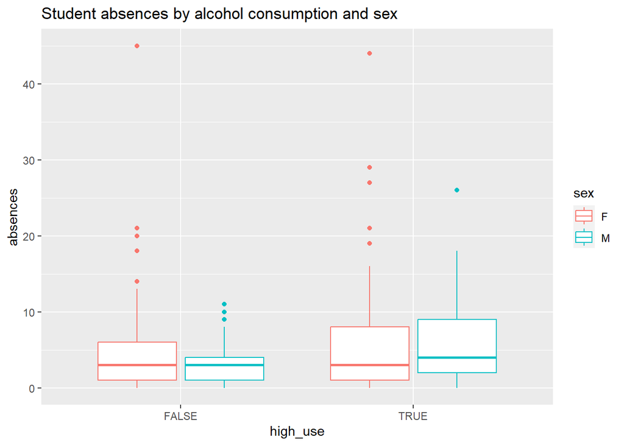

```r
# initialize a plot of high_use and absences
g2 <- ggplot(alc, aes(x= high_use, y= absences, col = sex))

# define the plot as a box plot and draw it
g2 + geom_boxplot() + ylab("absences") + ggtitle("Student absences by alcohol consumption and sex")
```

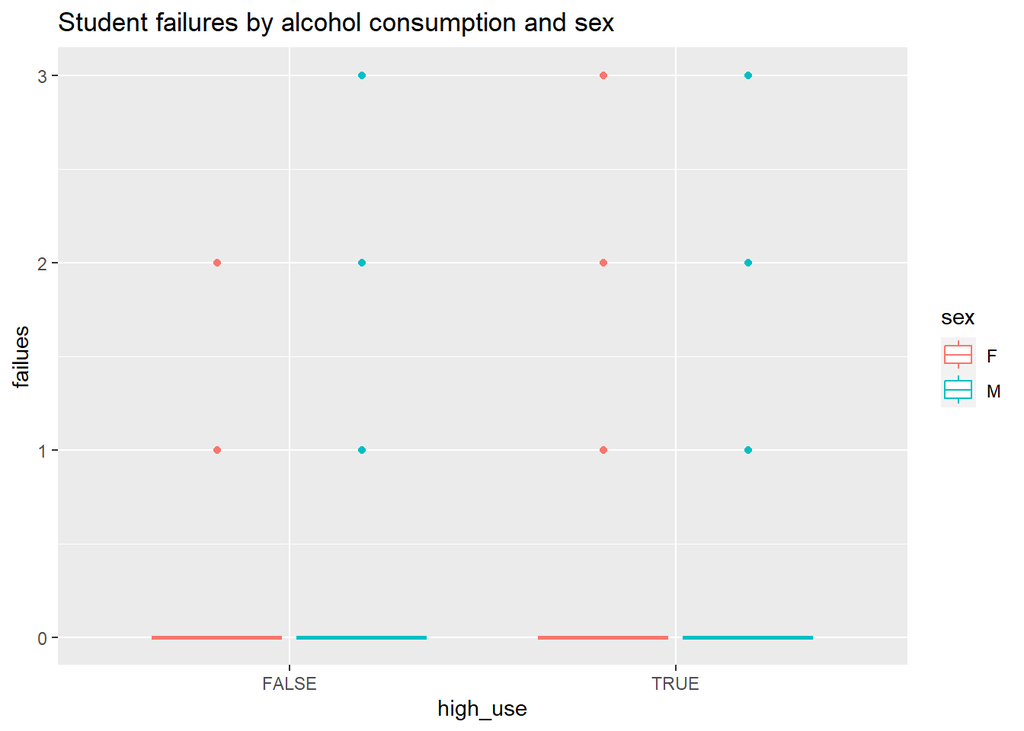

```r
# initialize a plot of high_use and failures
g3 <- ggplot (alc, aes(x = high_use, y = failures, col = sex))

# define the plot as a box plot and draw it
g3 + geom_boxplot() + ylab("failues") + ggtitle("Student failures by alcohol consumption and sex")
```

It seems that male are more likely to have high alcohol consumption than female. The results support my hypothesis 1 on the relationship between sex and alcohol use.The student final year grade by alcohol consumption and sex plot shows that higher G3 indicates lower use of alcohol, which supports the hypothesis 2. The plot, absences vs high_use, shows that higher absences relates to higher alcohol consumption, which supports the hypothesis 4. It seems that failures doesn’t have a relationship with alcohol consumption.

## Logistic regression

```r
# create logic regression
high_use_four <- glm(high_use ~ sex + G3 + failures + absences, data = alc, family = "binomial")


# print out the coefficients of the model
coef(high_use_four)
```

```
## (Intercept)        sexM          G3    failures    absences
## -1.38732604  1.00870144 -0.04670941  0.50382370  0.09057516
```

```r
# summary of model
summary(high_use_four)
```

```
##
## Call:
## glm(formula = high_use ~ sex + G3 + failures + absences, family = "binomial",
##     data = alc)
##
## Coefficients:
##             Estimate Std. Error z value Pr(>|z|)
## (Intercept) -1.38733    0.51617  -2.688  0.00719 **
## sexM         1.00870    0.24798   4.068 4.75e-05 ***
## G3          -0.04671    0.03948  -1.183  0.23671
## failures     0.50382    0.22018   2.288  0.02213 *
## absences     0.09058    0.02322   3.901 9.56e-05 ***
## ---
## Signif. codes:  0 '***' 0.001 '**' 0.01 '*' 0.05 '.' 0.1 ' ' 1
##
## (Dispersion parameter for binomial family taken to be 1)
##
##     Null deviance: 452.04  on 369  degrees of freedom
## Residual deviance: 405.59  on 365  degrees of freedom
## AIC: 415.59
##
## Number of Fisher Scoring iterations: 4
```

```r
# extract odds rations and confidence intervals
OR <- coef(high_use_four) %>% exp
CI <- confint(high_use_four) %>% exp
```

The odds of high alcohol use are about 2.74 higher for male compared to female. The p-value(4.75e-05) suggests that this effect is statistically significant. The variable G3 is not a significant predictor of high alcohol use in this model as the p-value is 0.24 > 0.05. An increase in the number of failures and absences is associated with a statistically significant increase in alcohol use. For each additional failure, the odds of high alcohol use increase by about 66% (odds ration = 1.66), for each additional absence, the odds of high alcohol use increase by about 10% (odds ration = 1.10).

The 95% confidence intervals for the odds rations are (1.684, 4.44) for sex, (0.882, 1.031) for G3, (1.074, 2.551) for failures, and (1.047, 1.145) for absences. The interval of G3 variable includes 1, presenting that the odds ratio is not statistically significant at the chosen level of confidence. Therefore, the variable G3 does not fit this model, the H2 is not supported, and other hypothesis are supported. Which means that sex, failure and absence fit this model.

## Explore the predictive power of model

```r
# fit the model
m <- glm(high_use ~ failures + absences + sex, data = alc, family = "binomial")

# predict() the probability of high_use
probabilities <- predict(m, type = "response")

library(dplyr)
# add the predicted probabilities to 'alc'
alc <- mutate(alc, probability = probabilities)

# use the probabilities to make a prediction of high_use
alc <- mutate(alc, prediction = probability > 0.5)

# see the last ten original classes, predicted probabilities, and class predictions
select(alc, failures, absences, sex, high_use, probability, prediction) %>% tail(10)
```

```
##     failures absences sex high_use probability prediction
## 361        0        3   M    FALSE   0.3392074      FALSE
## 362        1        0   M    FALSE   0.4142096      FALSE
## 363        1        7   M     TRUE   0.5745818       TRUE
## 364        0        1   F    FALSE   0.1359851      FALSE
## 365        0        6   F    FALSE   0.1999211      FALSE
## 366        1        2   F    FALSE   0.2388490      FALSE
## 367        0        2   F    FALSE   0.1472175      FALSE
## 368        0        3   F    FALSE   0.1592068      FALSE
## 369        0        4   M     TRUE   0.3602274      FALSE
## 370        0        2   M     TRUE   0.3188026      FALSE
```

```r
# tabulate the target variable versus the predictions
table(high_use = alc$high_use, prediction = alc$prediction)
```

```
##         prediction
## high_use FALSE TRUE
##    FALSE   252    7
##    TRUE     78   33
```

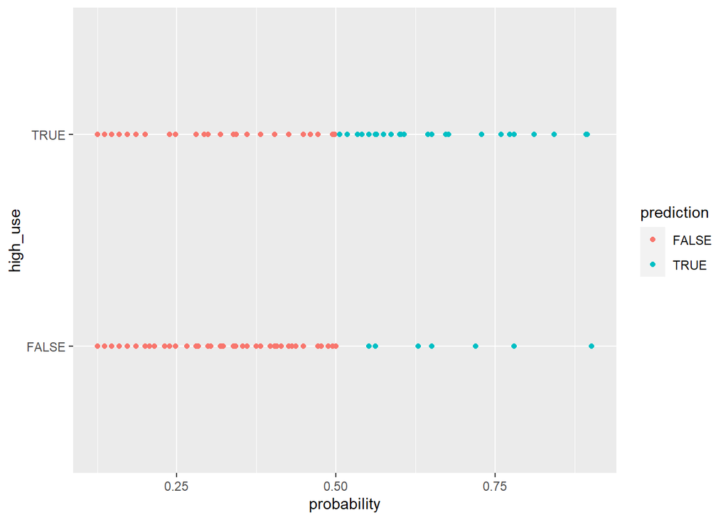

```r
# access ggplot2
library(ggplot2)

# initialize a plot of 'high_use' versus 'probability' in 'alc'
g <- ggplot(alc, aes(x = probability, y = high_use))

# define the geom as points and draw the plot
g + geom_point(aes(col = prediction))
```

```r
# tabulate the target variable versus the predictions
table(high_use = alc$high_use, prediction = alc$prediction) %>%
  prop.table() %>%
  addmargins()
```

```
##         prediction
## high_use      FALSE       TRUE        Sum
##    FALSE 0.68108108 0.01891892 0.70000000
##    TRUE  0.21081081 0.08918919 0.30000000
##    Sum   0.89189189 0.10810811 1.00000000
```

```r
# define a loss function (mean prediction error)
loss_func <- function(class, prob) {
  n_wrong <- abs(class - prob) > 0.5
  mean(n_wrong)
}

# call loss_func to compute the average number of wrong predictions in the (training) data
loss_func(class = alc$high_use, prob = 0)
```

```
## [1] 0.3
```

```r
# adjust the code
loss_func(class = alc$high_use, prob = 1)
```

```
## [1] 0.7
```

```r
# adjust the code
loss_func(class = alc$high_use, prob = alc$probability)
```

```
## [1] 0.2297297
```

## 10-fold cross-validation

```r
library(readr)
library(dplyr)
m <- glm(high_use ~ sex + failures + absences, data = alc, family = "binomial")
alc <- mutate(alc, probability = predict(m, type = "response"))
alc <- mutate(alc, prediction = probability > 0.5)

# define a loss function (average prediction error)
loss_func <- function(class, prob) {
  n_wrong <- abs(class - prob) > 0.5
  mean(n_wrong)
}

# compute the average number of wrong predictions in the (training) data
train_error <- loss_func(class = alc$high_use, prob = alc$probability)


# 10-fold cross-validation
library(boot)
cv_10_fold <- cv.glm(data = alc, cost = loss_func, glmfit = m, K = 10)

# average number of wrong predictions in the cross validation
cv_10_fold$delta[1]
```

```
## [1] 0.2378378
```

## Delete “sex” of the model

```r
# fit the model
m <- glm(high_use ~ failures + absences, data = alc, family = "binomial")

# predict() the probability of high_use
probabilities <- predict(m, type = "response")

library(dplyr)
# add the predicted probabilities to 'alc'
alc <- mutate(alc, probability = probabilities)

# use the probabilities to make a prediction of high_use
alc <- mutate(alc, prediction = probability > 0.5)

# see the last ten original classes, predicted probabilities, and class predictions
select(alc, failures, absences, high_use, probability, prediction) %>% tail(10)
```

```
##     failures absences high_use probability prediction
## 361        0        3    FALSE   0.2434520      FALSE
## 362        1        0    FALSE   0.3218450      FALSE
## 363        1        7     TRUE   0.4607833      FALSE
## 364        0        1    FALSE   0.2138489      FALSE
## 365        0        6    FALSE   0.2928056      FALSE
## 366        1        2    FALSE   0.3595604      FALSE
## 367        0        2    FALSE   0.2283128      FALSE
## 368        0        3    FALSE   0.2434520      FALSE
## 369        0        4     TRUE   0.2592578      FALSE
## 370        0        2     TRUE   0.2283128      FALSE
```

```r
# tabulate the target variable versus the predictions
table(high_use = alc$high_use, prediction = alc$prediction)
```

```
##         prediction
## high_use FALSE TRUE
##    FALSE   246   13
##    TRUE     93   18
```

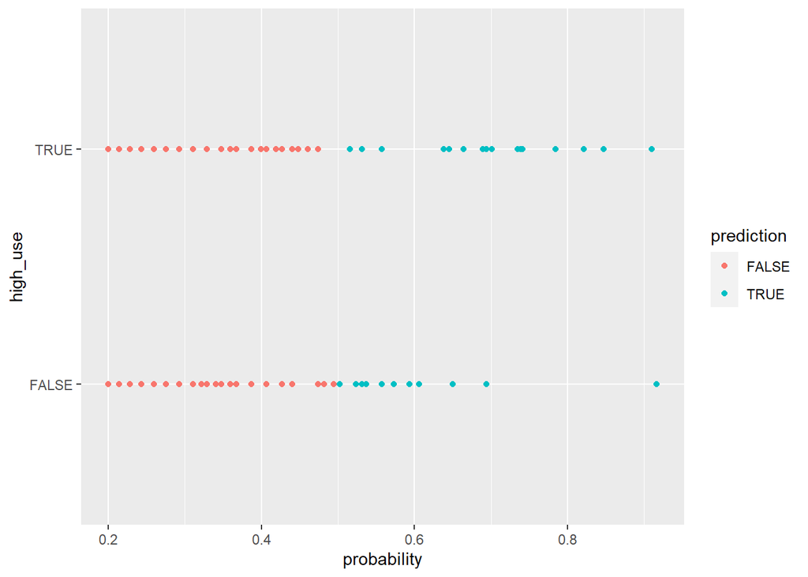

```r
# access ggplot2
library(ggplot2)

# initialize a plot of 'high_use' versus 'probability' in 'alc'
g <- ggplot(alc, aes(x = probability, y = high_use))

# define the geom as points and draw the plot
g + geom_point(aes(col = prediction))
```

```r
# tabulate the target variable versus the predictions
table(high_use = alc$high_use, prediction = alc$prediction) %>%
  prop.table() %>%
  addmargins()
```

```
##         prediction
## high_use      FALSE       TRUE        Sum
##    FALSE 0.66486486 0.03513514 0.70000000
##    TRUE  0.25135135 0.04864865 0.30000000
##    Sum   0.91621622 0.08378378 1.00000000
```

```r
# define a loss function (mean prediction error)
loss_func <- function(class, prob) {
  n_wrong <- abs(class - prob) > 0.5
  mean(n_wrong)
}

# call loss_func to compute the average number of wrong predictions in the (training) data
loss_func(class = alc$high_use, prob = 0)
```

```
## [1] 0.3
```

```r
# adjust the code
loss_func(class = alc$high_use, prob = 1)
```

```
## [1] 0.7
```

```r
# adjust the code
loss_func(class = alc$high_use, prob = alc$probability)
```

```
## [1] 0.2864865
```

The overall accuracy of this model is about 71.35%, training errors is about 28.65%, higher than original model.

## Delete failures of the model

```r
# fit the model
m <- glm(high_use ~ absences, data = alc, family = "binomial")

# predict() the probability of high_use
probabilities <- predict(m, type = "response")

library(dplyr)
# add the predicted probabilities to 'alc'
alc <- mutate(alc, probability = probabilities)

# use the probabilities to make a prediction of high_use
alc <- mutate(alc, prediction = probability > 0.5)

# see the last ten original classes, predicted probabilities, and class predictions
select(alc, absences, high_use, probability, prediction) %>% tail(10)
```

```
##     absences high_use probability prediction
## 361        3    FALSE   0.2682636      FALSE
## 362        0    FALSE   0.2193522      FALSE
## 363        7     TRUE   0.3432623      FALSE
## 364        1    FALSE   0.2349119      FALSE
## 365        6    FALSE   0.3235609      FALSE
## 366        2    FALSE   0.2512202      FALSE
## 367        2    FALSE   0.2512202      FALSE
## 368        3    FALSE   0.2682636      FALSE
## 369        4     TRUE   0.2860216      FALSE
## 370        2     TRUE   0.2512202      FALSE
```

```r
# tabulate the target variable versus the predictions
table(high_use = alc$high_use, prediction = alc$prediction)
```

```
##         prediction
## high_use FALSE TRUE
##    FALSE   254    5
##    TRUE    102    9
```

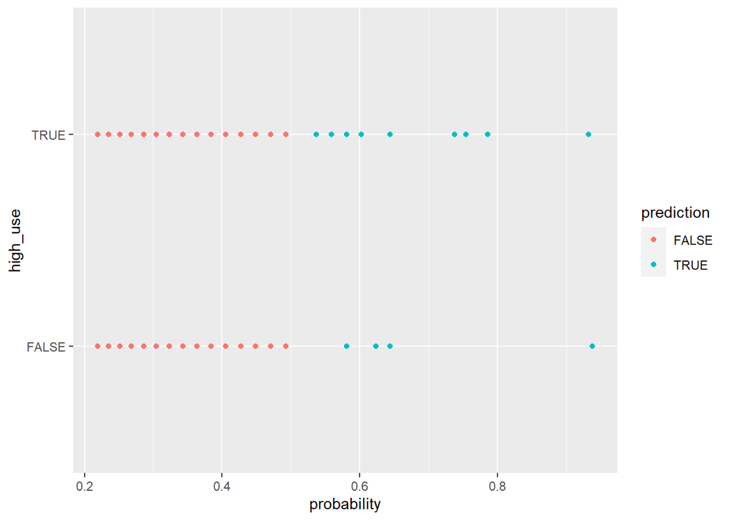

```r
# access ggplot2
library(ggplot2)

# initialize a plot of 'high_use' versus 'probability' in 'alc'
g <- ggplot(alc, aes(x = probability, y = high_use))

# define the geom as points and draw the plot
g + geom_point(aes(col = prediction))
```

```r
# tabulate the target variable versus the predictions
table(high_use = alc$high_use, prediction = alc$prediction) %>%
  prop.table() %>%
  addmargins()
```

```
##         prediction
## high_use      FALSE       TRUE        Sum
##    FALSE 0.68648649 0.01351351 0.70000000
##    TRUE  0.27567568 0.02432432 0.30000000
##    Sum   0.96216216 0.03783784 1.00000000
```

```r
# define a loss function (mean prediction error)
loss_func <- function(class, prob) {
  n_wrong <- abs(class - prob) > 0.5
  mean(n_wrong)
}

# call loss_func to compute the average number of wrong predictions in the (training) data
loss_func(class = alc$high_use, prob = 0)
```

```
## [1] 0.3
```

```r
# adjust the code
loss_func(class = alc$high_use, prob = 1)
```

```
## [1] 0.7
```

```r
# adjust the code
loss_func(class = alc$high_use, prob = alc$probability)
```

```
## [1] 0.2891892
```